# R_HW2

Annie Innes-Gold

4/3/2019

First I read in the three CSV files.

Then I created a summary plot for energy spending over time, organized by department. I found that the Department of Atomic Energy Defense and the Office of Science R & D consistently have the highest budget, while the others are grouped closer together, with Fusion Energy Sciences and Bio and Env Sciences most recently being at the bottom (Figure 1).

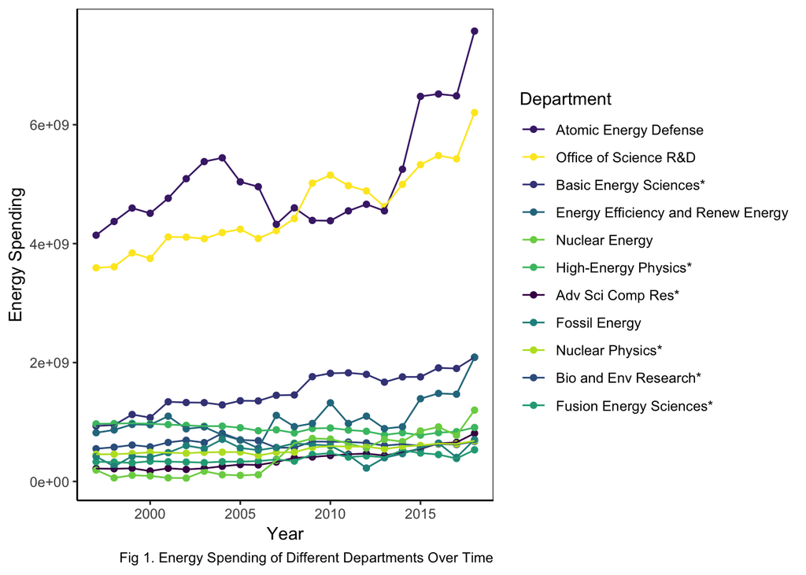

My next plot looked at GCC Spending over time organized by department. I found that NASA consistently spent the most, while the departments of Agricuture, Interior, and others were on the lower end (Figure 2).

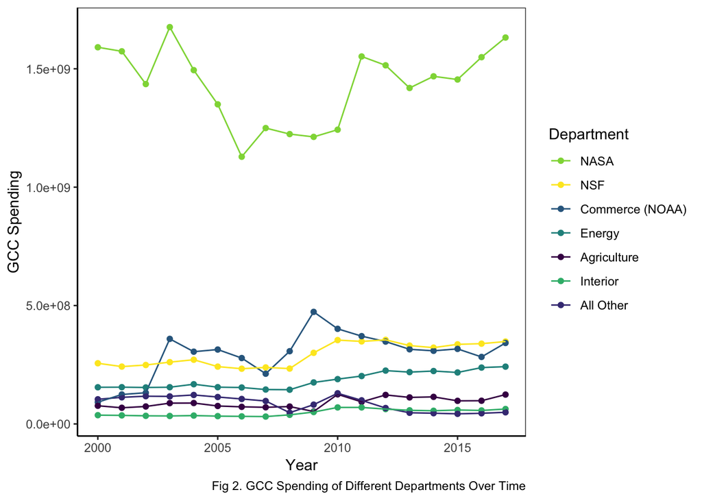

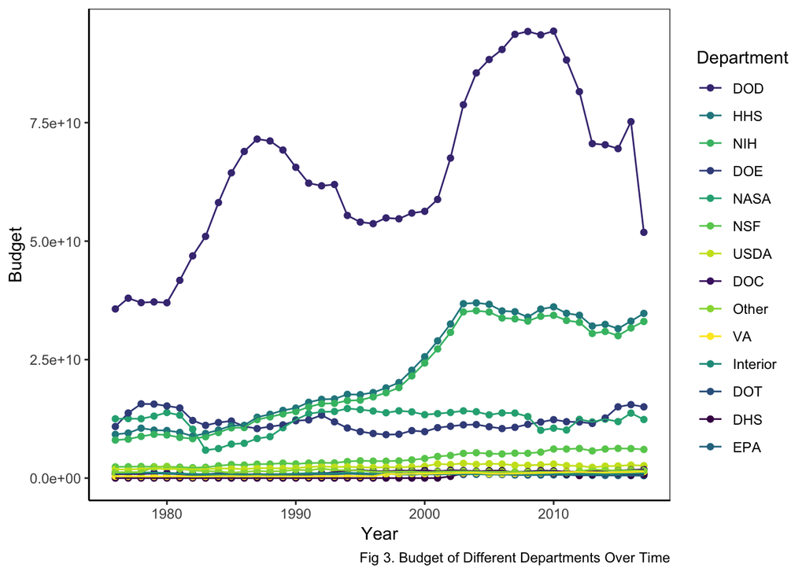

I decided to focus on the NSF. I wanted to see if there was a relationship between NSF Budget and NSF GCC Spending over time. I first summarized the NSF Budget over time, and their GCC Spending, and combined these two data sheets into one. I then wrote a function in order to create a plot that would display the adjusted R2 value and the P-value. I found a strong positive correlation between NSF Budget and NSF GCC Spending (Figure 4). NSF Budget accounted for 72% of the variation in NSF GCC Spending (Figure 4).

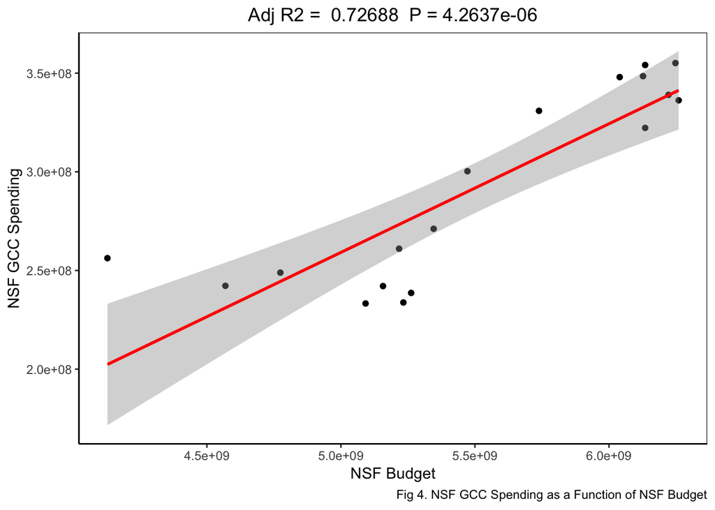

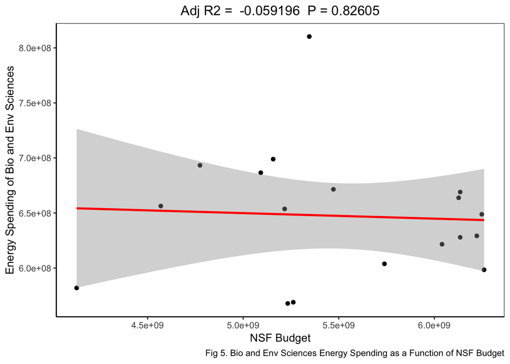